# Linear Regression

Jan Linke, Philipp Mildenberger

23 März 2020

$$\newcommand\xbar{\overline{x}}
\def\ybar{\overline{y}}
\def\eps{\epsilon}$$

# Chapter Overview

- Motivating Example
- Simple Linear Regression
- Multiple Linear Regression
- Other Considerations in the Regression Model
- Example expained
- Comparison to $K$-Nearest Neighbors

## Motivating Example

### Advertising Data

| TV | radio | newspaper | sales |
| --- | --- | --- | --- |
| 230.1 | 37.8 | 69.2 | 22.1 |
| 44.5 | 39.3 | 45.1 | 10.4 |
| 17.2 | 45.9 | 69.3 | 9.3 |
| 151.5 | 41.3 | 58.5 | 18.5 |
| 180.8 | 10.8 | 58.4 | 12.9 |
| 8.7 | 48.9 | 75 | 7.2 |

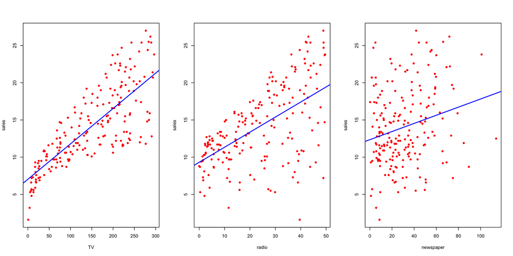

## Motivating Example

### Questions

- Is there a relationship between advertising budget and sales?
- How strong is the relationship between advertising budget and sales?
- Which media contribute to sales?
- How accurately (and precisely) can we estimate the effect of each medium?
- How accurately can we predict future sales?
- Is the relationship linear?
- Is there synergy (i.e. interaction) among the advertising media?

## Simple Linear Regression

Predict quantitative response $Y$ on the basis of $X$

$$Y \approx \beta_0 + \beta_1 X \qquad
Y = \beta_0 + \beta_1 X + \eps \quad \eps\stackrel{i.i.d.}= N(0,\sigma^2)$$

- $\beta_0$ is called “Intercept” and $\beta_1$ “slope”. Both are often called “coefficients” “parameters”
- Both are unknown, will be estimated

With estimates $\hat\beta_0$ , $\hat\beta_1$, one can then make predictions for $Y$ based on observed values of $X$:

$$\hat y = \hat \beta_0 + \hat\beta_1 x$$

## Estimating the Coefficients $\beta_0$ and $\beta_1$

- Let $y_i:=\hat \beta_0 + \hat\beta_1 x_i$ be the prediction for $Y$ based on the $i$-th value of $X$.
- The residual sum of squares (RSS) is defined as

$$\text{RSS}:= (y_1 - \hat y_1)^2 + \ldots + (y_n - \hat y_n)^2$$

with $\ybar:=\frac{1}{n}\sum_{i=1}^n y_i$ and $\xbar:=\frac{1}{n}\sum_{i=1}^n x_i$ the sample means. These are direct (i.e. non-iterative) calculations :)

## Advertising Example

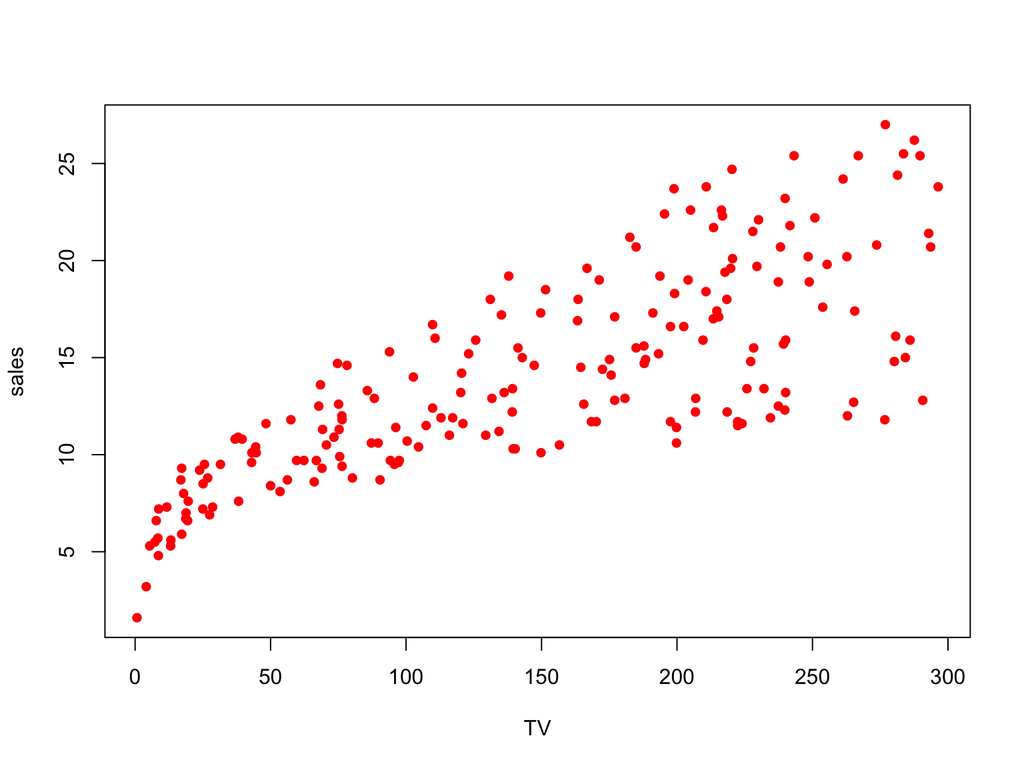

- Scatterplot of `sales` and `TV`

## Advertising Example

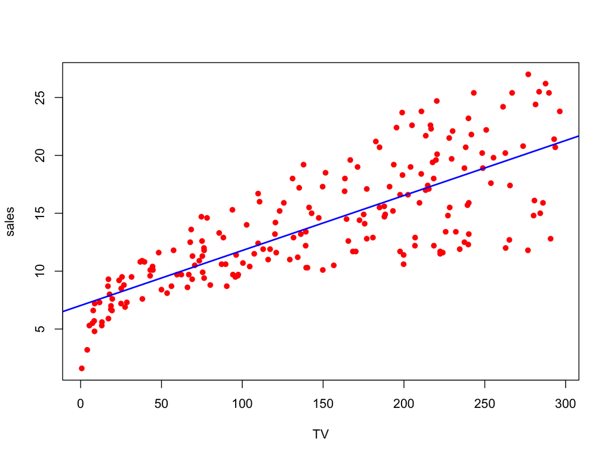

- Scatterplot of `sales` and `TV`
- Best linear fit to the data

## Advertising Example

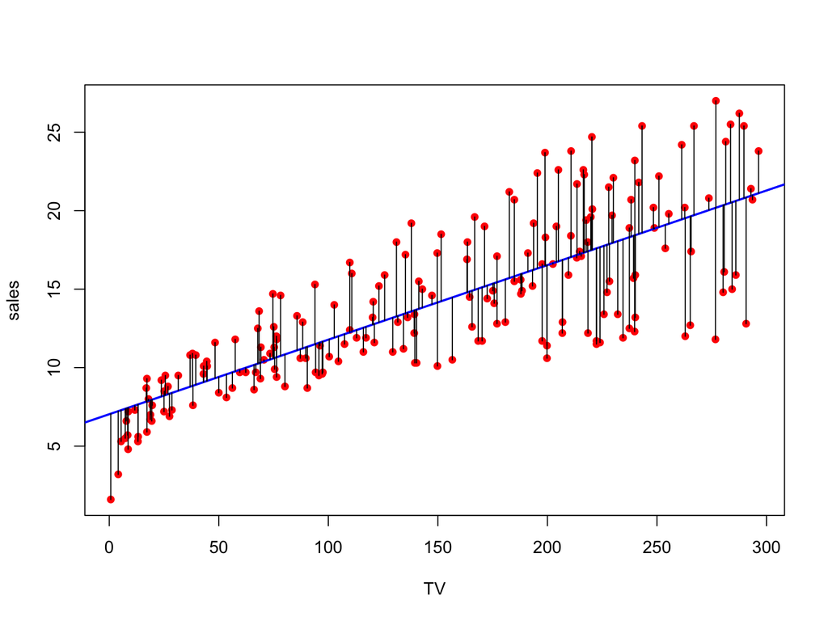

- Scatterplot of `sales` and `TV`
- Best linear fit to the data
- Residuals of the linear regression model

## Advertising Example

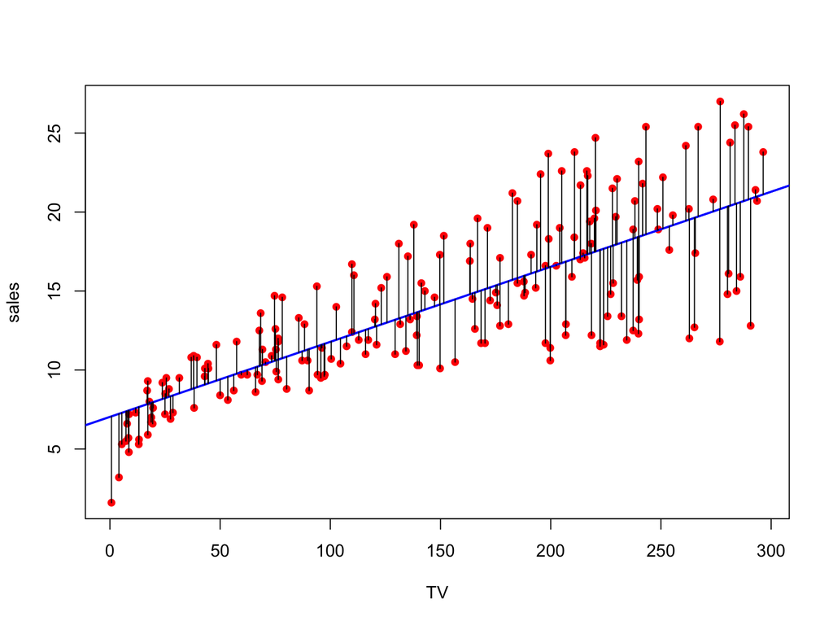

```r
lm(sales~TV, data=Advertising)
```

```
##
## Call:
## lm(formula = sales ~ TV, data = Advertising)
##
## Coefficients:
## (Intercept)           TV
##     7.03259      0.04754
```

## Assessing Accuracy of Coefficient Estimates

We want to know how much randomness went into a particular estimate produced by the estimator $\hat\beta_1$. The standard error quantifies that:

$$\text{SE}(\hat\beta_1)^2=\frac{\sigma^2}{\sum_{i=1}^n(x_i-\xbar)^2} \qquad
\text{SE}(\hat\beta_0)^2=\sigma^2\left[\frac 1 n + \frac{\xbar^2}{\sum_{i=1}^n(x_i-\xbar)^2}\right]$$
where $\sigma^2:=\text{Var}(\eps)$ is the variance of the the random error term.

- We observe
  - Higher $\sigma^2$ leads to larger SE
  - Higher Variance in $X$ leads to smaller SE
- $\sigma^2$ is unknown, but can be estimated with the residuals by

$$\hat\sigma^2:=\frac{RSS}{(n-2)}=\frac{\sum_{i=1}^n(y_i-\hat y_i)^2}{(n-2)}.$$

- The $-2$ in the denominator comes from the two degrees of freedom of the linear model.
  - standard error increases with number of predictors
- By replacing $\sigma^2$ with $\hat \sigma^2$ in the formulae above, we get an estimator $\widehat{\text{SE}}(\hat\beta_1)$ for $\text{SE}(\hat\beta_1)$. This estimator can then be used for the construction of *confidence intervals* or for *hypothesis testing*.

## Example to Accuracy Assessment

Assume the the true model has the form
$$Y = 2 + 3\cdot X + \eps \qquad \eps \stackrel{i.i.d.}{\sim}N(0,4^2)$$

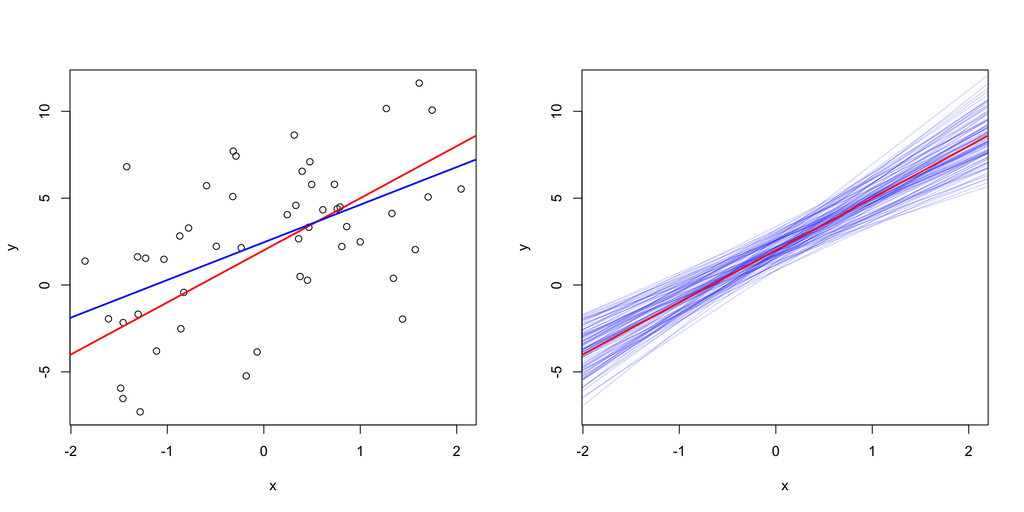

Left: sample of 50 observations. True regression line in red, sample based regression line in blue.  
Right: sample-based regression lines of 100 different samples

The estimated standard error of $\hat\beta_1$ is in this case:

$$\begin{aligned}
\hat\sigma^2 =& \frac{RSS}{n-2} \approx \frac{679.2}{48}= 14.15 \\
\widehat{SE}(\hat\beta_1) =& \sqrt{\frac{\hat\sigma^2}{\sum_{i=1}^n(x_i-\xbar)^2}}
\approx \sqrt{\frac{14.15}{55.7}} \approx 0.504
\end{aligned}$$

… which is the same as r shows us:

```r
pander::pander(lm0)
```

Fitting linear model: y ~ x

|  | Estimate | Std. Error | t value | Pr(>\|t\|) |
| --- | --- | --- | --- | --- |
| **(Intercept)** | 2.458 | 0.5321 | 4.62 | 2.898e-05 |
| **x** | 2.168 | 0.5041 | 4.3 | 8.327e-05 |

We saw above, that the estimate for $\sigma=\sqrt{14.15}\approx 3.76$ was a bit lower than the actual value of $4$. If we look at the 100 different samples, we get 100 estimates that vary around the true value. Their overall mean is 4.01108.  
That means: $\hat\sigma$ estimates $\sigma$ without bias.

## Hypothesis Testing

Standard error can be used to conduct *hypothesis tests* on the coefficients. Often, one wants to assess wheter there is an relationship between $X$ and $Y$, this is the same as testing whether the slope is equal to zero.

- **$H_0$**: $\beta_1=0$ i.e. there is no relationship between $X$ and $Y$
- **$H_A$**: $\beta_1\neq0$ i.e. there is some relationship between $X$ and $Y$

Under the assumption that the null hypothesis is true, we get a *t-statistic* with $n-2$ degrees of freedom.
$$t=\frac{\hat\beta_1 - 0}{\widehat{\text{SE}}(\hat\beta_1)} \qquad$$
This is $t$-distributed since we needed to estimate the standard error.

## Assessing the Accuracy of the Model

### Residual Standard Error (RSE)

The RSE is an estimate of the standard deviation of the random error $\eps$. It is the average amount the response will deviate from the true regression line.

$$\text{RSE}=\sqrt{\frac{1}{n-2}\text{RSS}}$$

### Variance Explained $R^2$

$R^2$ expresses the fraction of variance explained in $Y$.

$$R^2 = \frac{\text{TSS}-\text{RSS}}{\text{TSS}} = 1-\frac{\text{RSS}}{\text{TSS}}$$
We set $TSS:=\sum_{i=1}^n(y_i-\ybar)^2$ the total sum of squares.
In simple linear regression, $R^2$ equals the squared Pearson correlation.

### RSE versus $R^2$

$R^2$ is a relative value between 0 and 1,  
RSE is an absolute value to be interpreted in the units of the respone.

## Multiple Linear Regression

When there is more than one predictor, we could do many simple linear regressions. In the Advertising example:

Fitting linear model: sales ~ TV

|  | Estimate | Std. Error | t value | Pr(>\|t\|) |
| --- | --- | --- | --- | --- |
| **(Intercept)** | 7.033 | 0.4578 | 15.36 | 1.406e-35 |
| **TV** | 0.04754 | 0.002691 | 17.67 | 1.467e-42 |

Fitting linear model: sales ~ radio

|  | Estimate | Std. Error | t value | Pr(>\|t\|) |
| --- | --- | --- | --- | --- |
| **(Intercept)** | 9.312 | 0.5629 | 16.54 | 3.561e-39 |
| **radio** | 0.2025 | 0.02041 | 9.921 | 4.355e-19 |

Fitting linear model: sales ~ newspaper

|  | Estimate | Std. Error | t value | Pr(>\|t\|) |
| --- | --- | --- | --- | --- |
| **(Intercept)** | 12.35 | 0.6214 | 19.88 | 4.714e-49 |
| **newspaper** | 0.05469 | 0.01658 | 3.3 | 0.001148 |

BUT:

- We end up with multiple (possibly contradicting) predictions for one observation (market)
- It ignores the relationship between the predictors

## Multiple Linear Regression

So with multiple predictors the model is:

$$Y=\beta_0 + \beta_1X_1 + \cdots + \beta_pX_p + \eps$$

We interpret $\beta_j$ as the average eﬀect on $Y$ of a one unit increase in $X_j$, holding all other predictors ﬁxed. $p$ is the number of predictors in the model.

Similar to simple linear regression one can make predictions using the formula

$$\hat y_i = \hat \beta_0 + \hat\beta_1x_{i1} + \cdots + \hat\beta_px_{ip}$$

where the estimators are obtained by minimizing the RSS:

$$\text{RSS}:= (y_1 - \hat y_1)^2 + \ldots + (y_n - \hat y_n)^2$$

## Multiple Linear Regression Advertising Example

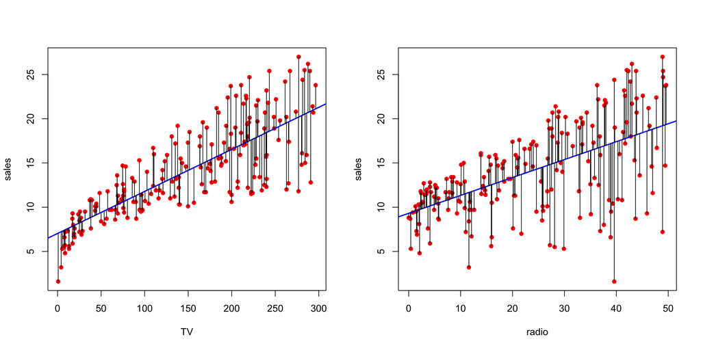

[interactive chart not shown]

[output not shown]

[output not shown]

## Multiple Linear Regression Advertising Example

The coefficients for a model for `sales` with `TV`, `radio` and `newspaper` look like this:

Fitting linear model: sales ~ TV + radio + newspaper

|  | Estimate | Std. Error | t value | Pr(>\|t\|) |
| --- | --- | --- | --- | --- |
| **(Intercept)** | 2.939 | 0.3119 | 9.422 | 1.267e-17 |
| **TV** | 0.04576 | 0.001395 | 32.81 | 1.51e-81 |
| **radio** | 0.1885 | 0.008611 | 21.89 | 1.505e-54 |
| **newspaper** | -0.001037 | 0.005871 | -0.1767 | 0.8599 |

`newspaper` seems no longer to have an effect on `sales`. The correlation between `newspaper` and `radio` is $0.35$.

|  | TV | radio | newspaper | sales |
| --- | --- | --- | --- | --- |
| **TV** | 1 | 0.05481 | 0.05665 | 0.7822 |
| **radio** |  | 1 | 0.3541 | 0.5762 |
| **newspaper** |  |  | 1 | 0.2283 |
| **sales** |  |  |  | 1 |

## Some Important Questions

1. Is at least one of the predictors useful in predicting the response?
2. Do all the predictors help explain $Y$, or is only a subset of the predictors useful?
3. How well does the model fit the data?
4. Given a set of predictor values, what response value should we predict, and how accurate is our prediction?

## 1. Is there a Relationship Between the Repsone and Predictors?

Use the $F$-statistic:

$$F=\frac{(\text(TSS)-\text{RSS})/p}{\text{RSS}/(n-p-1)} \quad \sim F_{p,n-p-1}$$

- avoids multiple tests for each predictor
- If subset of predictors is taken for granted, the $F$-statistic can also be uesd to test whether additional parameters are useful.

## 2. Do we need all predictors?

- First we need am method to judge the quality of models
  - $F$-test, AIC, BIC, adjusted $R^2$, …
  - all methods have in common that they introduce some ‘penalty’ for the number of predictors
- Then, we need a procedure to models of different subsets of predictors
  - compare all subsets
  - forward selection
  - backward selection
  - mixed forward&backward selection

## 3. How well does the model fit the data?

Most common are RSE and $R^2$, which we’ve seen for simple linear regression

### $R^2$

| TV: $0.612$ | Radio: $0.332$ | Newspaper: $0.052$ |
| --- | --- | --- |
| TV&Radio: $0.897$ | Radio&Newspaper: $0.333$ | TV&Newspaper: $0.646$ |
|  | TV&Radio&Newspaper: $0.897$ |  |

### RSE

| TV: $3.259$ | Radio: $4.275$ | Newspaper: $5.092$ |
| --- | --- | --- |
| TV&Radio: $1.681$ | Radio&Newspaper: $4.284$ | TV&Newspaper: $3.121$ |
|  | TV&Radio&Newspaper: $1.686$ |  |

- Newspaper leads little or no change in $R^2$ and to higher *RSE* even.
- Note: Adding an additional predictor cannot decrease $R^2$ (by design).

## 4. How accurate are our predictions?

Given some values for $X$ we can make predictions for $Y$. If, for example, 100000 is spent on `TV` and 20000 is spent on `radio`, the expected `sales` are $11.26$ units:

$$\hat y = \hat\beta_0 + \hat\beta_1 x_1 + \hat\beta_2 x_2 =
\hat\beta_0 + \hat\beta_1 \mathtt{TV} + \hat\beta_2 \mathtt{radio} = 11.26$$

There are three levels of uncertainty:

1. Reducible error: $\hat beta$s are estimates
2. Model bias: The true relationship is seldom exactly linear
3. Irreducible error: The random error term $\eps$ reflects

```r
predict(lmTVRadio,
        data.frame(TV=100,radio=20,newspaper=0),
        interval = "prediction")
```

```
##        fit      lwr      upr
## 1 11.25647 7.929616 14.58332
```

```r
predict(lmTVRadio,
        data.frame(TV=100,radio=20,newspaper=0),
        interval = "confidence")
```

```
##        fit      lwr      upr
## 1 11.25647 10.98525 11.52768
```

## Small Excursus: Matrix Notation and Hat Matrix

Linear model in matrix notation:

$$\underbrace{\left(\begin{smallmatrix} y_1 \\ \vdots \\ y_n \end{smallmatrix}\right)}_{=:Y} =
\underbrace{\left(\begin{smallmatrix}
1 & x_{11} & \ldots & x_{1p} \\
\vdots & \vdots & & \vdots \\
1 & x_{n1} & \ldots & x_{np}
\end{smallmatrix}\right)}_{=:X} \cdot
\underbrace{\left(\begin{smallmatrix}
\beta_0 \\ \vdots \\ \beta_p
\end{smallmatrix}\right)}_{=:\beta} +
\underbrace{\left(\begin{smallmatrix}
\eps_1 \\ \vdots \\ \eps_n
\end{smallmatrix}\right)}_{\stackrel{i.i.d.}\sim \,\,\, N(0,\sigma^2)}$$

$X$ is called *design matrix*. The least squares estimator for the coefficients can then be expressed as

$$\hat \beta = \underbrace{(X^T X)^{-1}X^T }_{\small{\text{ Pseudoinverse of }} X} \cdot Y$$

The predictions for $Y$ based on $X$ are then

$$\hat Y = X\hat \beta = X (X^T X)^{-1}X^T \cdot Y := H \cdot Y$$

where $H$ is called *prediction* or *hat matrix*. $H$ contains a lot of useful information, most importantly: The values on the main diagonal are the **leverages** of each observation.

## Other Considerations in the Regression Model

### Qualitative Predictors

- often part of the Predictors are qualitative, not quantitative.

**Example:** Credit data set

- **quantitative predictors:** records balance (average credit card debt), age, number of credit cards, education, income, credit limit and credit rating
- **qualitative predictors:** gender, student, status (marital status) and ethnicity

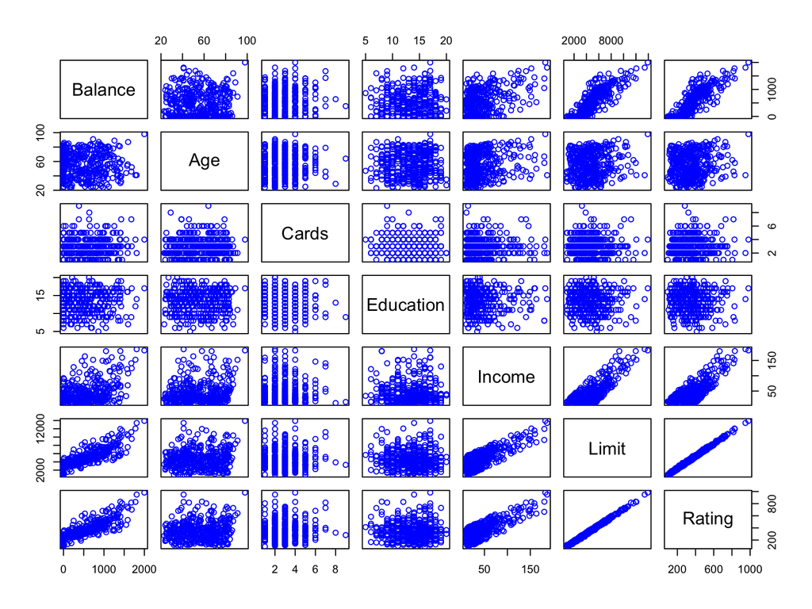

## Qualitative Predictors

###Predictors with Only Two Levels

- incorporation in regression model is simple.
- create indicator (dummy variable) taking on two dummy numerical values

Example:

- credit card balance between males and females (ignoring other variables)

$$\begin{equation}
x_{i}=\left\{\begin{array}{ll}
1 & \text { if } i \text { th person is female } \\
0 & \text { if } i \text { th person is male }
\end{array}\right.
\end{equation}$$

## Qualitative Predictors

###Predictors with Only Two Levels

- insert dummy variable as predictor in regression equation:

$$\begin{equation}
y_{i}=\beta_{0}+\beta_{1} x_{i}+\epsilon_{i}=\left\{\begin{array}{ll}
\beta_{0}+\beta_{1}+\epsilon_{i} & \text { if } i \text { th person is female } \\
\beta_{0}+\epsilon_{i} & \text { if } i \text { th person is male. }
\end{array}\right.
\end{equation}$$

- $\beta_{0}$ interpretable as average credit card balance among males
- $\beta_{0}$ + $\beta_{1}$ as average credit card balance among females
- $\beta_{1}$ as average difference in credit card balance

|  | X | Coefficient | Std..error | t.statistic | p.value |
| --- | --- | --- | --- | --- | --- |
| 1 | Intercept | 509.8 | 33.13 | 15.389 | &lt; 0.0001 |
| 2 | gender(Female) | 19.73 | 46.05 | 0.429 | 0.6690 |

=> dummy p-value high  
=> no difference between genders

## Qualitative Predictors

###Qualitative Predictors with More than Two Levels

- qualitative predictor with more than two levels
- single dummy variable cannot represent all possible values

=> create multiple dummy variables

####Creditcard example:

ethnicity:

- $x_{i1}$ = 1 if asian, 0 if not asian
- $x_{i2}$ = 1 if caucasian, 0 if not caucasian

=> always one dummy variable less than number of levels  
=> level without dummy = baseline

## Qualitative Predictors

###Qualitative Predictors with More than Two Levels

$$\begin{equation}
y_{i}=\beta_{0}+\beta_{1} x_{i 1}+\beta_{2} x_{i 2}+\epsilon_{i}=\left\{\begin{array}{ll}
\beta_{0}+\beta_{1}+\epsilon_{i} & \text { if } i \text { th person is Asian } \\
\beta_{0}+\beta_{2}+\epsilon_{i} & \text { if } i \text { th person is Caucasian } \\
\beta_{0}+\epsilon_{i} & \text { if } i \text { th person is African American. }
\end{array}\right.
\end{equation}$$

- $\beta_{0}$ average credit card balance for African Americans
- $\beta_{1}$ difference in average balance between Asian and African American
- $\beta_{2}$ difference in average balance between Caucasian and African American

## Qualitative Predictors

###Qualitative Predictors with More than Two Levels

|  | X | Coefficient | Std.error | t.statistic | p.value |
| --- | --- | --- | --- | --- | --- |
| 1 | Intercept | 531 | 46.32 | 11.464 | &lt; 0.0001 |
| 2 | ethnicity(Asian) | -18.69 | 65.02 | -0.287 | 0.7740 |
| 3 | ethnicity(Caucasian) | -12.5 | 56.68 | -0.221 | 0.8260 |

=> large p-values: no statistical evidence for a real difference in credit card balance

Hypothesis test via F-test: **$H_{0}$: $\beta_{1}$ = $\beta_{2}$** = 0 (p-value of 0.96)

=> $H_{0}$ not rejectable  
=> no relationship between balance and ethnicity

## Extensions of the Linear Model

###Assumptions of the linear regression

- standard linear regression model:

$$\begin{equation}
Y=\beta_{0}+\beta_{1}X_{1}+\beta_{2}X_{2}+...+\beta_{p}X_{p}+\epsilon
\end{equation}$$

- interpretable, reliable for real-world problems
- highly restrictive assumptions
- Additive: effect of changes in predictor $X_{j}$ on response Y independent of other predictors.
- Linear: change in response Y due to one-unit change in $X_{j}$ is constant,  
  regardless of value of $X_{j}$

  => often violated
- **Solution:** Extend the linear model!

## Extensions of the Linear Model

###Removing the Additive Assumption

- Example marketing:

$$\begin{equation}
\text{sales}= \beta_{0}+\beta_{1}\times \text{TV}+\beta_{2}\times \text{radio}+\beta_{3}\times \text{newspaper}+\epsilon
\end{equation}$$
- states that average effect on sales of one-unit increase in TV is always $\beta_{1}$ (independent from radio)

- **Possibly wrong:**
- Increase in radio might affect the increase in TV  
  (50/50 budget might lead to higher sales than 100/0)

=> synergy effect (marketing) / interaction effect (statistics)  
=> model tends to underestimate sales

## Extensions of the Linear Model

- standard linear regression model with two variables:

$$\begin{equation}
Y=\beta_{0}+\beta_{1} X_{1}+\beta_{2} X_{2}+\epsilon
\end{equation}$$

- increase $X_{1}$ by one unit -> $Y$ increase by average of $\beta_{1}$ units (regardless of $X_{2}$)

**Solution:**

- include a third predictor (interaction term): product of $X_{1}$ and $X_{2}$

## Extensions of the Linear Model

$$\begin{equation}
Y=\beta_{0}+\beta_{1} X_{1}+\beta_{2} X_{2}+\beta_{3} X_{1} X_{2}+\epsilon
\end{equation}$$

rewritten as:

$$\begin{equation}
\begin{aligned}
Y &=\beta_{0}+\left(\beta_{1}+\beta_{3} X_{2}\right) X_{1}+\beta_{2} X_{2}+\epsilon \\
&=\beta_{0}+\tilde{\beta}_{1} X_{1}+\beta_{2} X_{2}+\epsilon
\end{aligned}
\end{equation}$$

where $\tilde\beta_{1}$ = $\beta_{1}$ + $\beta_{3}X_{2}$

=> $\tilde\beta_{1}$ changes with $X_{2}$

=> effect of $X_{1}$ on $Y$ no longer constant

## Extensions of the Linear Model

####Example 1:

- linear model with interaction between radio and TV

$$\begin{equation}
\begin{aligned}
\text { sales } &=\beta_{0}+\beta_{1} \times \mathrm{TV}+\beta_{2} \times \text { radio }+\beta_{3} \times(\text { radio } \times \mathrm{TV})+\epsilon \\
&=\beta_{0}+\left(\beta_{1}+\beta_{3} \times \text { radio }\right) \times \mathrm{TV}+\beta_{2} \times \text { radio }+\epsilon
\end{aligned}
\end{equation}$$

- $\beta_{3}$ as increase in effectiveness of TV for one unit increase in radio (or vice-versa)

## Extensions of the Linear Model

|  | X | Coefficient | Std.error | t.statistic | p.value |
| --- | --- | --- | --- | --- | --- |
| 1 | Intercept | 6.7502 | 0.248 | 27.23 | &lt; 0.0001 |
| 2 | TV | 0.0191 | 0.002 | 12.7 | &lt; 0.0001 |
| 3 | radio | 0.0289 | 0.009 | 3.24 | 0.0014 |
| 4 | TV x radio | 0.0011 | 0 | 20.73 | &lt; 0.0001 |

=> results suggest that the new model is superior to the old

- p-value for interaction extremely low

**=> strong evidence for $H_a$ : $\beta_{3}$ $\neq$ 0**  
**=> true relationship not additive**

## Extensions of the Linear Model

####Example 2:

- predict number of units produced based on production lines and workers:

  -> likely that production lines dependent on workers  
  -> include interaction term between lines and workers
- fit model:

$$\begin{equation}
\begin{aligned}
\text { units } & \approx 1.2+3.4 \times \text { lines }+0.22 \times \text { workers }+1.4 \times(\text { lines } \times \text { workers }) \\
&=1.2+(3.4+1.4 \times \text { workers }) \times \text { lines }+0.22 \times \text { workers }
\end{aligned}
\end{equation}$$

**=> adding 1 line increases produced product by 3.4 + 1.4 × workers**

**=> more workers lead to a stronger effect of lines**

## Extensions of the Linear Model

####Non-linear Relationships

- linear regression model assumes linear relationship between response and predictors
- **BUT:** true relationship nonlinear
- **solution:** extend linear model to accommodate non-linear relationships via polynomial regression

-> include transformed versions of predictors in model

## Potential Problems

###1. Non-linearity of the Data

- true relationship might be far from linear

-> every conclusion drawn from model fit might be wrong, as well as reduced prediction accuracy  
-> residual plots to identify non linearity

- simple linear regression model: plot residuals $e_{i} = y_{i} − \hat y_{i}$, vs predictor $x_{i}$
- multiple regression model: plot residuals vs predicted/fitted values $\hat y_{i}$
- Ideally: no discernible pattern in residual plot  
  (patterns indicate problems with aspects of the linear model)
- If residual plot indicates non-linearity  
  -> use non-linear transformations of predictors (log $X, √X$, and $X²$) in regression model

## Potential Problems

###2. Correlation of Error Terms

- standard errors for estimated regression coefficients or fitted values are based  
  on the assumption of uncorrelated error terms
- if errors are uncorrelated:  
  -> i = positive provides little/no information about i+1
- if errors are correlated:  
  -> estimated standard errors tend to underestimate true standard errors

=> confidence/prediction intervals will be narrower

=> p-values in model are lower than reality -> conclusion about significance of parameters potentially wrong

=> overall model confidence will be too big

## Potential Problems

###Occurence & Detection

- correlation often occurs in context of time series data:  
  -> observations obtained at discrete points in time

  => adjacent time points often have correlated errors
- Detection of correlation:

-> plot residuals as a function of time

- **if errors are uncorrelated:** no discernible pattern
- **else:** tracking in residuals (adjacent residuals have similar values)

## Potential Problems

###3. Non-constant Variance of Error Terms

- non-constant variances in errors (heteroscedasticity)  
  -> standard errors, confidence intervals and hypothesis test rely on constant variance
- detectable through a funnel shape in residual plot
- **solution:** transform response Y with a concave function (e.g. log Y or √ Y)

  => greater shrinkage of larger responses => reduction in heteroscedasticity

## Potential Problems

Variance of each response might be known:

- example: every ith response = average of $n_{i}$ raw observations
- if each raw observation is uncorrelated with variance $\sigma^{2}$, the average has the variance

$$\begin{equation}
\sigma_{i}^{2}=\sigma^{2} / n
\end{equation}$$

- **solution:** fit model by weighted least squares  
  (weights proportional to inverse weighted variances)

## Potential Problems

###4. Outliers

- outliers: $y_{i}$ far from value predicted by the model
- if an outlier has no unusual predictor value -> little effect on least squares fit.

**BUT:**

- RSE increases with outliers => important for fit interpretation
- $R^{2}$ decreases with outlier

## Potential Problems

**Outlier detection:**

- Residual plots -> sometimes difficult to decide what is an outlier
- **instead:** plot studentized residuals (divide each residual $e_{i}$ by its estimated standard error)

  => observation with studentized residuals greater than 3 in absolute value are possible outliers
- **possible solution:** if due to an error in data collection or recording => remove the outlier
- **BUT:** outlier may indicate a deficiency in model

## Potential Problems

###5. High Leverage Points

- High leverage observation have unusual values for $x_{i}$  
  => sizable impact on estimated regression line  
  => too many can impact the entire fit
- for simple linear regression, high leverage is easy to identify  
  -> predictor value outside of normal range
- for multiple linear regression with many predictors, the observation might be unusual in the full set of predictors  
  -> quantify an observation’s leverage through leverage statistic  
  (high value = high leverage)

## Potential Problems

- simple linear regression:

$$\begin{equation}
h_{i}=\frac{1}{n}+\frac{\left(x_{i}-\bar{x}\right)^{2}}{\sum_{i^{\prime}=1}^{n}\left(x_{i^{\prime}}-\bar{x}\right)^{2}}
\end{equation}$$

- $h_{i}$ increases with distance of $x_{i}$ from $\tilde x$
- $h_{i}$ always between $\frac 1n$ and 1, average leverage for all observations always equal to $\frac {(p + 1)} n$  
  -> if observations statistic >> $\frac {(p + 1)} n$, leverage might be high

## Potential Problems

###6. Collinearity

- 2 or more predictor variables are closely related to eachother
- problem: difficult to separate out individual effects on the response of collinear variables

  or: the limit and rating increase / decrease together  
  -> association with response difficult to determine
- collinearity reduces accuracy of estimates of regression coefficients  
  -> standard error for $\tilde\beta_j$ grows
- t-statistic for predictor calculated by dividing $\tilde\beta_j$ by its standard error -> collinearity results in decline in t-statistic.

  => possible failure to reject $H_0$ : $\beta_j$ = 0  
  => reducing power of hypothesis test
- **Detection:** predictors with large absolute values in the correlation matrix indicate a pair of highly correlated variables

## Potential Problems

- **BUT:** collinearity may exist between three and more variables  
  (even without a pair of variables with high correlation)  
  => so called multicollinearity
- assession of multicollinearity: variance inflation factor (VIF)

$$\begin{equation}
\operatorname{VIF}\left(\hat{\beta}_{j}\right)=\frac{1}{1-R_{X_{j} | X_{-j}}^{2}}
\end{equation}$$

where $R^{2}_{Xj}$ = $R^2$ from a regression of $X_j$ onto all other predictors

- VIF > 5 or 10: problematic amount of collinearity
- **solutions:**
- drop one problematic variable from regression  
  => little effect on the regression, since collinear variable redundant  
  => combine collinear variables into a single predictor

## The Marketing Plan

**1. Relationship between advertising sales and budget?**

- fit multiple regression model of sales onto TV, radio, and newspaper

$$\begin{equation}
sales= \beta_{0}+\beta_{1}\times TV+\beta_{2}\times radio+\beta_{3}\times newspaper+\epsilon
\end{equation}$$

- test $H_0$ : $\beta_{TV}$ = $\beta_{radio}$ = $\beta_{newspaper}$ = 0
- F-statistic to determine if $H_0$ rejected  
  here: p-value very low  
  => relationship between advertising and sales present

## The Marketing Plan

**2. How strong is the relationship?**

Two measures for model accuracy:  
- **Residual Standard Error:** estimates standard deviation of the response from population regression line

- for Advertising:  
  RSE = 1,681 units  
  mean value for response = 14,022

=> percentage error roughly 12 %.

- **$R^2$ statistic**: shows what percentage of variability in the response is explained by the predictors

=> 90 % of variance in sales

## The Marketing Plan

**3. Which media contribute to sales?**

- in multiple linear regression:

p-values for TV and radio low (< 0.001)

p-value for newspaper not (0.8599)

=> only TV and radio related to sales

## The Marketing Plan

**4. How large is the effect of each medium on sales?**

- standard error of $\hat\beta_j$ usable to construct confidence intervals for $\beta_j$
- Advertising data 95% confidence intervals:  
  TV: (0.043, 0.049)  
  radio: (0.172, 0.206)  
  newspaper (−0.013, 0.011)

  => confidence intervals for TV / radio are narrow and $\neq$ 0 -> **related to sales**

  => newspaper includes 0 -> **variable not statistically significant**

## The Marketing Plan

**Collinearity responsible for the wide standard errors and the confidence interval of newspaper?**

- VIF scores:

  1.005 (TV)  
  1.145 (radio)  
  1.145 (newspaper)

-> no evidence of collinearity

- association of each medium on sales: 3 simple linear regressions

**Results:** strong association between TV and sales and between radio and sales

-> only mild association between newspaper and sales and only when TV and radio are ignored

## The Marketing Plan

**5. How accurately can we predict future sales?**

- accuracy of estimates depends on …

… prediction of individual response:

$$\begin{equation}
Y=f(X)+\epsilon
\end{equation}$$

=> prediction intervals

… average response

f(X)

=> confidence intervals

Prediction intervals usually larger than confidence intervals  
-> account for uncertainty of irreducible error

## The Marketing Plan

**6. Is the Relationship linear?**

- Display the residual plots a pattern?

if no -> linear relationship

if yes -> non-linear relationship

**Advertising data:** non-linear effects present

## The Marketing Plan

**7. Is there Synergy among advertising media?**

**Standard linear regression model:**

- additive relationship between predictors and response, no interaction among predictors

-> might be unrealistic for certain datasets

**Inclusion of an interaction term:**

- allows for accommodation of non-additive relationships

-> small p-value of interaction term indicates presence of such relationships

=> advertising data: interaction term increases $R^2$ from 90% to 97% in the model

## Comparison of Linear Regression with K-Nearest Neighbors

**Linear regression**

Parametric approach (assumes linear functional form f(X))

**Advantages:**  
- easy to fit (estimate small number of coefficients)  
- coefficients with simple interpretations  
- tests of statistical significance easily performed

**disadvantage:**  
- strong assumptions about the form of f(X)  
-> if specified form far from truth, prediction accuracy decreases  
=> poor fit

## Comparison of Linear Regression with K-Nearest Neighbors

**Non-parametric methods**:

no explicit assumptions for parametric form for f(X)

-> more flexible approach for performing regression

**K-nearest neighbors regression (KNN regression)**

1. get the values for K and the prediction point $x_{0}$,
2. identify K training observations closest to $x_0$ ($N_0$)
3. estimate f($x_0$) with average of all training responses in $N_0$

$$\begin{equation}
\hat{f}\left(x_{0}\right)=\frac{1}{K} \sum_{x_{i} \in \mathcal{N}_{0}} y_{i}
\end{equation}$$

## Comparison of Linear Regression with K-Nearest Neighbors

**Optimal value for K?**

Bias-variance tradeoff:

small K = most flexible fit  
->low bias  
->high variance  
=> prediction in a given region may depend on only one observation

large K = smoother, less variable fit  
=> may cause a bias, since smoothing can mask structures of f(X)

## Comparison of Linear Regression with K-Nearest Neighbors

**When does a parametric approach perform better than a non-parametric?**

=> when the parametric form is close to the true form of $f$

For a more linear relationship:

- If K is large, KNN performs only slightly worse than least squares regression
- For smaller Ks, the performance grows worse

**BUT:** the true relationship between X and Y is rarely exactly linear

- with increasing extent of non-linearity …

…comes little change in mean squared error (MSE) for the non-parametric (KNN method)

…comes an increase in test set MSE of linear regression

## Comparison of Linear Regression with K-Nearest Neighbors

**The Curse of dimensionality**

KNN performs worse in higher dimensions  
-> spreading observations over higher dimensions = reduction in sample size

=> K observations nearest to given test observation $x_0$ may be very far away from $x_0$ in p-dimensional space when p is large

=> poor prediction of f($x_0$), poor KNN fit

**general rule:** parametric methods outperform non-parametric in the case of few observations per predictor

Also, when the test MSE of KNN is only slightly lower than the test MSE of linear regression…

…linear regression is still easier to interpret